# Introducción a DataViz con Python

DataViz Python Data

Da tus primeros pasos en el desarrollo de visualizaciones con Python.

[figure not shown]

La programación es una habilidad que puede ser adquirida de manera autodidacta, pero a veces uno no sabe como empezar. Por lo cual te dejo este curso online realizado en el 2020 📆 en conjunto con [EANT](https://eant.tech/escuela-de-ciencias-de-datos), el cual en solo **3 horas** ⏱️ podes dar tus primeros pasos en el desarrollo de visualizaciónes con **Python**🐍.

# ¿Que es Python ?

**Python** es un lenguaje de programación de código abierto, orientado a objetos, muy simple y fácil de entender. Tiene una sintaxis sencilla que cuenta con una vasta biblioteca de herramientas, que hacen de **Python** un lenguaje de programación único. La primera publicación de **Python** se produce hace ya 30 años, ya que en 1989 Guido Van Rossum comenzó el desarrollo de un nuevo lenguaje de programación casi por hobby y tomando su nombre de el grupo humorístico británico Monty Python.

Actualmente es uno de los lenguajes más utilizados para análisis de datos, pero también es considerado un lenguaje multi-proposito debido a gran cantidad de aplicaciónes que se pueden desarrollar con **Python**.

[figure not shown]

Más información sobre [Python](https://www.python.org/)

# ¿Que es Google Colab ?

[figure not shown]

**Google Colab** es una **IDE** (Entorno de desarrollo integrado) para poder progrmar en Python utilizando google drive.

Es un marco de desarrollo amigable, el cual permite:

- Autocompletado
- Reconocimiento de sintaxis de programación
- Depurador de errores
- Tiene librerias preinstaladas
- Se utiliza desde drive lo cual permite versionar tu codigo y trabajar en conjunto con otros colaboradoes.

Para conocer más sobre **Colab** puedes copiar esta notebook: [Notebook](https://colab.research.google.com/notebooks/intro.ipynb)

[figure not shown]

En este workshop utilizamos 🐼pandas + 📊 seaborn + 📊 Plotly y podras realizar visualizaciones interactivas como la siguiente…

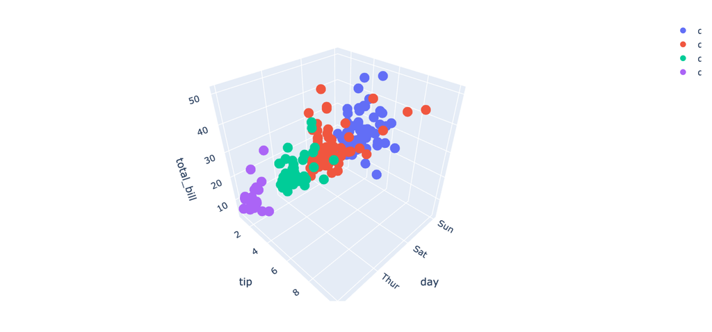

## Recursos

- ✏️ [Presentación](https://github.com/r0mymendez/Workshop-Eant-Data-Analytics-Python/blob/master/Data%20Analytics%20con%20Python.pdf)
- 🙀 [Github Repo](https://github.com/r0mymendez/Workshop-Eant-Data-Analytics-Python)
- 🔗 Acceso al curso Online: [Workshop EANT](https://eant.tech/escuela-de-ciencias-de-datos/cursos/taller-introduccion-a-data-analytics-python)

Comment on this article